# Factors Affecting Flight Delays and Cancellations

##### Explantory Visualizations

#### by Judith Agara

## Investigation Overview

> For the presentation, I focus on presenting plots that answer the following questions:
> - When is the best time of day/day/week/time of year to fly to minimise delays?
> - What is the top reason for flight cancellations?
> - Are there certain airlines that are home to more delays or cancellations?

## Dataset Overview

> After preliminary wrangling, I had a master dataset of **5,503,507** records (rows) and **18** features (columns) distributed across quantitative and qualitative datatypes. The delayed flights subset contains **1467596** records (rows) and the cancelled flights subset contains **33477** records.

## Time of Day with the most Flight Delays

> Evening, noon and night flights are the most delayed (36% of Evening flights are delayed, 31% of Noon and Night flights are delayed. 23% of morning flights are delayed, 21% of late night flights are delayed and 15% of morning flights are delayed).

> Evening, Night and Noon flights are also the most cancelled.

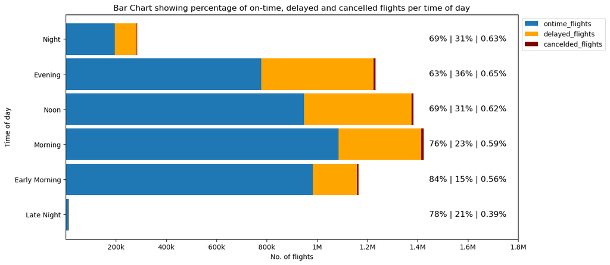

## Day of Week with the most Flight Delays

> Fridays and Thursdays have the highest percentages of delayed and cancelled flights.

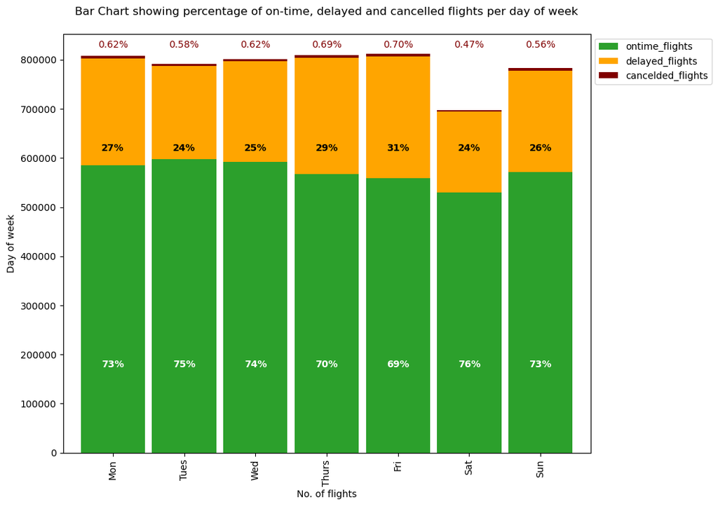

## Month of year with the most Flight Delays

> **December, October, June and July** have the most delays while **December, January and February** have the most cancellations.

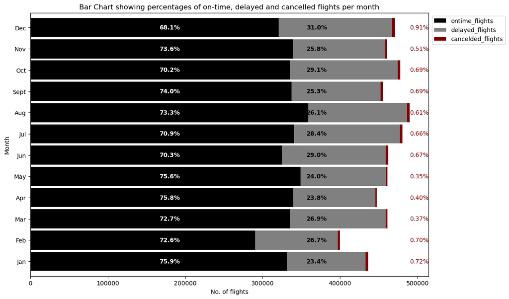

## Top reason for flight cancellation

> The top reason for flight cancellation is the carrier (airline).

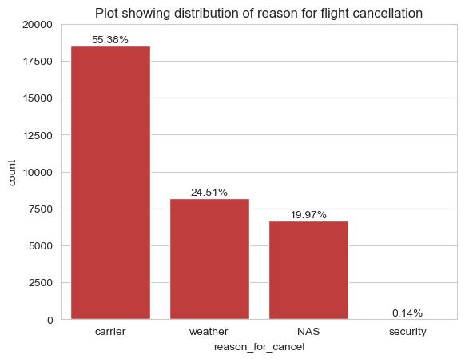

> Atlantic Southeast Airlines has the most delays (over 36%). It is followed be American Eagle Airlines with about 30% of scheduled flights delayed.

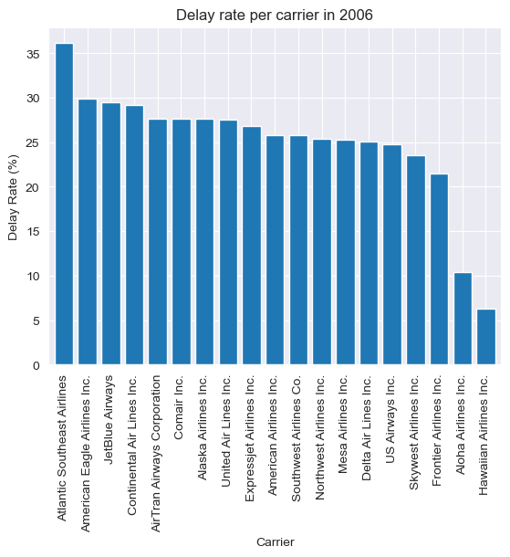

Mesa Airlines followed by Atlantic Southeast Airlines has the most cancellations. Atlantic Southeast Airlines is associated with lots of delays and cancellations and concidentally when looking at cities, Atlanta is home to more delays.

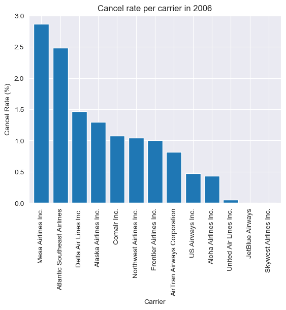